# RNAseq: Proyecto final

Joel Rodriguez Herrera (joelrh-lcg)

# Definir set de datos de trabajo

```r
library('recount3')
rawData <- available_projects()
```

```
## 2021-03-01 04:17:17 caching file sra.recount_project.MD.gz.
```

```
## 2021-03-01 04:17:22 caching file gtex.recount_project.MD.gz.
```

```
## 2021-03-01 04:17:25 caching file tcga.recount_project.MD.gz.
```

```r
rawData
```

| project | organism | file_source | project_home | project_type | n_samples |
| --- | --- | --- | --- | --- | --- |
| SRP107565 | human | sra | data_sources/sra | data_sources | 216 |
| SRP149665 | human | sra | data_sources/sra | data_sources | 4 |
| SRP017465 | human | sra | data_sources/sra | data_sources | 23 |
| SRP119165 | human | sra | data_sources/sra | data_sources | 6 |
| SRP133965 | human | sra | data_sources/sra | data_sources | 12 |
| SRP096765 | human | sra | data_sources/sra | data_sources | 7 |
| SRP124965 | human | sra | data_sources/sra | data_sources | 12 |
| SRP189165 | human | sra | data_sources/sra | data_sources | 15 |
| SRP050365 | human | sra | data_sources/sra | data_sources | 10 |
| SRP123065 | human | sra | data_sources/sra | data_sources | 41 |

[output cut: 8732 more lines]

Se ha elegido el set de datos correspondiente al experimento SRP075318 que busca determinar los genes clave involucrados en la espermatogénesis con el fin de poder mejorar el diagnóstico y tratamiento de la infertilidad masculina ocasionada por desordenes de la espermatogénesis.

Más información en: https://www.refine.bio/experiments/SRP075318/homo-sapiens-transcriptome-or-gene-expression

# Extracción de datos

```r
proj_info <- subset(
    rawData,
    project == "SRP075318" & project_type == "data_sources"
)
rse_gene_SRP075318 <- create_rse(proj_info)
```

```
## 2021-03-01 04:17:35 downloading and reading the metadata.
```

```
## 2021-03-01 04:17:37 caching file sra.sra.SRP075318.MD.gz.
```

```
## 2021-03-01 04:17:40 caching file sra.recount_project.SRP075318.MD.gz.
```

```
## 2021-03-01 04:17:41 caching file sra.recount_qc.SRP075318.MD.gz.
```

```
## 2021-03-01 04:17:43 caching file sra.recount_seq_qc.SRP075318.MD.gz.
```

```
## 2021-03-01 04:17:45 caching file sra.recount_pred.SRP075318.MD.gz.
```

```
## 2021-03-01 04:17:47 downloading and reading the feature information.
```

```
## 2021-03-01 04:17:47 caching file human.gene_sums.G026.gtf.gz.
```

```
## 2021-03-01 04:17:49 downloading and reading the counts: 12 samples across 63856 features.
```

```
## 2021-03-01 04:17:51 caching file sra.gene_sums.SRP075318.G026.gz.
```

```
## 2021-03-01 04:17:52 construcing the RangedSummarizedExperiment (rse) object.
```

```r
rse_gene_SRP075318
```

```
## class: RangedSummarizedExperiment
## dim: 63856 12
## metadata(8): time_created recount3_version ... annotation recount3_url
## assays(1): raw_counts
## rownames(63856): ENSG00000278704.1 ENSG00000277400.1 ...
##   ENSG00000182484.15_PAR_Y ENSG00000227159.8_PAR_Y
## rowData names(10): source type ... havana_gene tag
## colnames(12): SRR3543511 SRR3543512 ... SRR3538932 SRR3538933
## colData names(175): rail_id external_id ...
##   recount_pred.curated.cell_line BigWigURL
```

Obteneos la cuenta de lecturas a partir de la cuentas de nucleotidos:

```r
assay(rse_gene_SRP075318, "counts") <- compute_read_counts(rse_gene_SRP075318)
rse_gene_SRP075318
```

```
## class: RangedSummarizedExperiment
## dim: 63856 12
## metadata(8): time_created recount3_version ... annotation recount3_url
## assays(2): raw_counts counts
## rownames(63856): ENSG00000278704.1 ENSG00000277400.1 ...
##   ENSG00000182484.15_PAR_Y ENSG00000227159.8_PAR_Y
## rowData names(10): source type ... havana_gene tag
## colnames(12): SRR3543511 SRR3543512 ... SRR3538932 SRR3538933
## colData names(175): rail_id external_id ...
##   recount_pred.curated.cell_line BigWigURL
```

En el estudio se consideran 63,856 genes en 12 muestras.

## Revision de datos extraídos

```r
rowData(rse_gene_SRP075318)
```

```
## DataFrame with 63856 rows and 10 columns
##                            source     type     score     phase
##                          <factor> <factor> <numeric> <integer>
## ENSG00000278704.1         ENSEMBL     gene      2237        NA
## ENSG00000277400.1         ENSEMBL     gene      2179        NA
## ENSG00000274847.1         ENSEMBL     gene      1599        NA
## ENSG00000277428.1         ENSEMBL     gene       101        NA
## ENSG00000276256.1         ENSEMBL     gene      2195        NA
## ...                           ...      ...       ...       ...
## ENSG00000124334.17_PAR_Y   HAVANA     gene      2504        NA
## ENSG00000185203.12_PAR_Y   HAVANA     gene      1054        NA
## ENSG00000270726.6_PAR_Y    HAVANA     gene       773        NA
## ENSG00000182484.15_PAR_Y   HAVANA     gene      4618        NA
## ENSG00000227159.8_PAR_Y    HAVANA     gene      1306        NA
##                                         gene_id              gene_type
##                                     <character>            <character>
## ENSG00000278704.1             ENSG00000278704.1         protein_coding
## ENSG00000277400.1             ENSG00000277400.1         protein_coding
## ENSG00000274847.1             ENSG00000274847.1         protein_coding
## ENSG00000277428.1             ENSG00000277428.1               misc_RNA
## ENSG00000276256.1             ENSG00000276256.1         protein_coding
## ...                                         ...                    ...
## ENSG00000124334.17_PAR_Y ENSG00000124334.17_P..         protein_coding
## ENSG00000185203.12_PAR_Y ENSG00000185203.12_P..              antisense
## ENSG00000270726.6_PAR_Y  ENSG00000270726.6_PA..   processed_transcript
## ENSG00000182484.15_PAR_Y ENSG00000182484.15_P.. transcribed_unproces..
## ENSG00000227159.8_PAR_Y  ENSG00000227159.8_PA.. unprocessed_pseudogene
##                            gene_name       level          havana_gene
##                          <character> <character>          <character>
## ENSG00000278704.1         BX004987.1           3                   NA
## ENSG00000277400.1         AC145212.2           3                   NA
## ENSG00000274847.1         AC145212.1           3                   NA
## ENSG00000277428.1              Y_RNA           3                   NA
## ENSG00000276256.1         AC011043.1           3                   NA
## ...                              ...         ...                  ...
## ENSG00000124334.17_PAR_Y        IL9R           2 OTTHUMG00000022720.1
## ENSG00000185203.12_PAR_Y      WASIR1           2 OTTHUMG00000022676.3
## ENSG00000270726.6_PAR_Y  AJ271736.10           2 OTTHUMG00000184987.2
## ENSG00000182484.15_PAR_Y      WASH6P           2 OTTHUMG00000022677.5
## ENSG00000227159.8_PAR_Y     DDX11L16           2 OTTHUMG00000022678.1
##                                  tag
##                          <character>
## ENSG00000278704.1                 NA
## ENSG00000277400.1                 NA
## ENSG00000274847.1                 NA
## ENSG00000277428.1                 NA
## ENSG00000276256.1                 NA
## ...                              ...
## ENSG00000124334.17_PAR_Y         PAR
## ENSG00000185203.12_PAR_Y         PAR
## ENSG00000270726.6_PAR_Y          PAR
## ENSG00000182484.15_PAR_Y         PAR
## ENSG00000227159.8_PAR_Y          PAR
```

Revisamos que los atributos de las muestras sean uniformes para que no haya muestras con atibutos distintos.

```r
rse_gene_SRP075318$sra.sample_attributes[1:5]
```

```
## [1] "age;;25|biomaterial_provider;;Department of Urology, Ren Ji Hospital, School of Medicine, Shanghai Jiao Tong University, 1633 Dongfang Road,|BioSampleModel;;Human|isolate;;primary_spermatocytes_replicate_1|sex;;male|tissue;;testis"
## [2] "age;;30|biomaterial_provider;;Department of Urology, Ren Ji Hospital, School of Medicine, Shanghai Jiao Tong University, 1634 Dongfang Road,|BioSampleModel;;Human|isolate;;primary_spermatocytes_replicate_2|sex;;male|tissue;;testis"
## [3] "age;;30|biomaterial_provider;;Department of Urology, Ren Ji Hospital, School of Medicine, Shanghai Jiao Tong University, 1637 Dongfang Road,|BioSampleModel;;Human|isolate;;spermatids_replicate_2|sex;;male|tissue;;testis"
## [4] "age;;26|biomaterial_provider;;Department of Urology, Ren Ji Hospital, School of Medicine, Shanghai Jiao Tong University, 1638 Dongfang Road,|BioSampleModel;;Human|isolate;;spermatids_replicate_3|sex;;male|tissue;;testis"
## [5] "age;;25|biomaterial_provider;;Department of Urology, Ren Ji Hospital, School of Medicine, Shanghai Jiao Tong University, 1639 Dongfang Road,|BioSampleModel;;Human|isolate;;undifferentiated_spermatogonias_1|sex;;male|tissue;;testis"
```

```r
rse_gene_SRP075318 <- expand_sra_attributes(rse_gene_SRP075318)
colData(rse_gene_SRP075318)[
    ,
    grepl("^sra_attribute", colnames(colData(rse_gene_SRP075318)))
]
```

```
## DataFrame with 12 rows and 6 columns
##            sra_attribute.age sra_attribute.biomaterial_provider
##                  <character>                        <character>
## SRR3543511                25             Department of Urolog..
## SRR3543512                30             Department of Urolog..
## SRR3543515                30             Department of Urolog..
## SRR3543516                26             Department of Urolog..
## SRR3543517                25             Department of Urolog..
## ...                      ...                                ...
## SRR3543514                25             Department of Urolog..
## SRR3543518                30             Department of Urolog..
## SRR3543519                26             Department of Urolog..
## SRR3538932                30             Department of Urolog..
## SRR3538933                26             Department of Urolog..
##            sra_attribute.BioSampleModel  sra_attribute.isolate
##                             <character>            <character>
## SRR3543511                        Human primary_spermatocyte..
## SRR3543512                        Human primary_spermatocyte..
## SRR3543515                        Human spermatids_replicate_2
## SRR3543516                        Human spermatids_replicate_3
## SRR3543517                        Human undifferentiated_spe..
## ...                                 ...                    ...
## SRR3543514                        Human spermatids_replicate_1
## SRR3543518                        Human undifferentiated_spe..
## SRR3543519                        Human undifferentiated_spe..
## SRR3538932                        Human Sertoli_cells_replic..
## SRR3538933                        Human Sertoli_cells_replic..
##            sra_attribute.sex sra_attribute.tissue
##                  <character>          <character>
## SRR3543511              male               testis
## SRR3543512              male               testis
## SRR3543515              male               testis
## SRR3543516              male               testis
## SRR3543517              male               testis
## ...                      ...                  ...
## SRR3543514              male               testis
## SRR3543518              male               testis
## SRR3543519              male               testis
## SRR3538932              male               testis
## SRR3538933              male               testis
```

Vemos que algunos de los datos no corresponden con el tipo de dato que deberían de ser, debemos hacer una corrección.

```r
colData(rse_gene_SRP075318)[1,]
```

```
## DataFrame with 1 row and 181 columns
##              rail_id external_id       study sra.sample_acc.x
##            <integer> <character> <character>      <character>
## SRR3543511   1200415  SRR3543511   SRP075318       SRS4197474
##            sra.experiment_acc sra.submission_acc  sra.submission_center
##                   <character>        <character>            <character>
## SRR3543511         SRX5191376          SRA426758 Chinese National Hum..
##               sra.submission_lab        sra.study_title     sra.study_abstract
##                      <character>            <character>            <character>
## SRR3543511 sequencing Department Homo sapiens Raw seq.. Many infertile men a..
##            sra.study_description   sra.experiment_title sra.design_description
##                        <logical>            <character>            <character>
## SRR3543511                    NA primary_spermatocyte.. Total RNA was extrac..
##            sra.sample_description sra.library_name sra.library_strategy
##                         <logical>      <character>          <character>
## SRR3543511                     NA             SPC1              RNA-Seq
##            sra.library_source sra.library_selection sra.library_layout
##                   <character>           <character>        <character>
## SRR3543511     TRANSCRIPTOMIC                RANDOM             paired
##            sra.paired_nominal_length sra.paired_nominal_stdev
##                            <logical>                <numeric>
## SRR3543511                        NA                        0
##            sra.library_construction_protocol  sra.platform_model
##                                    <logical>         <character>
## SRR3543511                                NA Illumina HiSeq 2500
##             sra.sample_attributes sra.experiment_attributes sra.spot_length
##                       <character>                 <logical>       <integer>
## SRR3543511 age;;25|biomaterial_..                        NA             300
##            sra.sample_name sra.sample_title sra.sample_bases sra.sample_spots
##                <character>        <logical>        <numeric>        <integer>
## SRR3543511            SPC1               NA       9587697586         31747343
##              sra.run_published   sra.size sra.run_total_bases
##                    <character>  <numeric>           <numeric>
## SRR3543511 2016-06-05 01:01:08 6313303576          9587697586
##            sra.run_total_spots sra.num_reads sra.num_spots
##                      <integer>     <integer>     <integer>
## SRR3543511            31747343             2      31747343
##                     sra.read_info sra.run_alias sra.run_center_name
##                       <character>   <character>           <logical>
## SRR3543511 index:0,count:317473..          SPC1                  NA
```

[output cut: 315 more lines]

```
##            recount_pred.pattern.predict.type recount_pred.pred.type
##                                  <character>            <character>
## SRR3543511                           rna-seq                rna-seq
##            recount_pred.curated.cell_type recount_pred.curated.cell_line
##                                 <logical>                      <logical>
## SRR3543511                             NA                             NA
##                         BigWigURL sra_attribute.age
##                       <character>       <character>
## SRR3543511 http://duffel.rail.b..                25
##            sra_attribute.biomaterial_provider sra_attribute.BioSampleModel
##                                   <character>                  <character>
## SRR3543511             Department of Urolog..                        Human
##             sra_attribute.isolate sra_attribute.sex sra_attribute.tissue
##                       <character>       <character>          <character>
## SRR3543511 primary_spermatocyte..              male               testis
```

# Trabajo sobre los datos: limpieza y normalización

## Corrección de tipo de datos

En este caso solo es necesario corregir la edad, ya que los demás atributos como el sexo o el tejido son iguales para cada muestra

```r
rse_gene_SRP075318$sra_attribute.age <- as.numeric(rse_gene_SRP075318$sra_attribute.age)
```

```r
# tenemos aislados para diferentes etapas de la espermatogénesis
table(rse_gene_SRP075318$sra_attribute.isolate)
```

```
##
## primary_spermatocytes_replicate_1 primary_spermatocytes_replicate_2
##                                 1                                 1
## primary_spermatocytes_replicate_3         Sertoli_cells_replicate_1
##                                 1                                 1
##         Sertoli_cells_replicate_2         Sertoli_cells_replicate_3
##                                 1                                 1
##            spermatids_replicate_1            spermatids_replicate_2
##                                 1                                 1
##            spermatids_replicate_3 undifferentiated_spermatogonias_1
##                                 1                                 1
## undifferentiated_spermatogonias_2 undifferentiated_spermatogonias_3
##                                 1                                 1
```

```r
rse_gene_SRP075318$assigned_gene_prop <- rse_gene_SRP075318$recount_qc.gene_fc_count_all.assigned / rse_gene_SRP075318$recount_qc.gene_fc_count_all.total
summary(rse_gene_SRP075318$assigned_gene_prop)
```

```
##    Min. 1st Qu.  Median    Mean 3rd Qu.    Max.
##  0.3652  0.5044  0.5618  0.5592  0.6195  0.7211
```

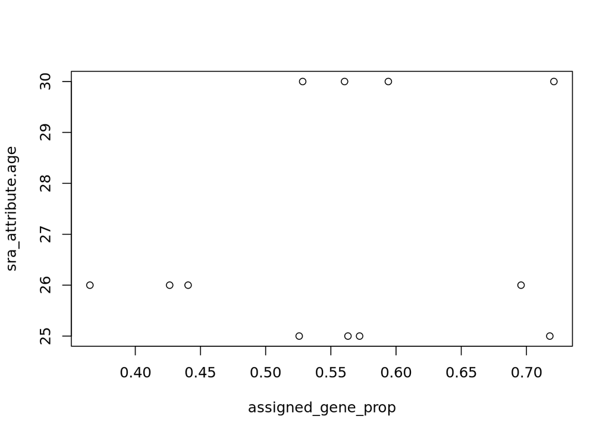

```r
with(colData(rse_gene_SRP075318), plot(assigned_gene_prop, sra_attribute.age))
```

Vemos que no existe una co-relación evidente.

Veamos las diferencias entre aislados:

```r
with(colData(rse_gene_SRP075318), tapply(assigned_gene_prop, sra_attribute.isolate, summary))
```

```
## $primary_spermatocytes_replicate_1
##    Min. 1st Qu.  Median    Mean 3rd Qu.    Max.
##  0.5257  0.5257  0.5257  0.5257  0.5257  0.5257
##
## $primary_spermatocytes_replicate_2
##    Min. 1st Qu.  Median    Mean 3rd Qu.    Max.
##  0.5284  0.5284  0.5284  0.5284  0.5284  0.5284
##
## $primary_spermatocytes_replicate_3
##    Min. 1st Qu.  Median    Mean 3rd Qu.    Max.
##  0.3652  0.3652  0.3652  0.3652  0.3652  0.3652
##
## $Sertoli_cells_replicate_1
##    Min. 1st Qu.  Median    Mean 3rd Qu.    Max.
##  0.5631  0.5631  0.5631  0.5631  0.5631  0.5631
##
## $Sertoli_cells_replicate_2
##    Min. 1st Qu.  Median    Mean 3rd Qu.    Max.
##  0.5605  0.5605  0.5605  0.5605  0.5605  0.5605
##
## $Sertoli_cells_replicate_3
##    Min. 1st Qu.  Median    Mean 3rd Qu.    Max.
##  0.4405  0.4405  0.4405  0.4405  0.4405  0.4405
##
## $spermatids_replicate_1
##    Min. 1st Qu.  Median    Mean 3rd Qu.    Max.
##   0.572   0.572   0.572   0.572   0.572   0.572
##
## $spermatids_replicate_2
##    Min. 1st Qu.  Median    Mean 3rd Qu.    Max.
##  0.5941  0.5941  0.5941  0.5941  0.5941  0.5941
##
## $spermatids_replicate_3
##    Min. 1st Qu.  Median    Mean 3rd Qu.    Max.
##  0.4264  0.4264  0.4264  0.4264  0.4264  0.4264
##
## $undifferentiated_spermatogonias_1
##    Min. 1st Qu.  Median    Mean 3rd Qu.    Max.
##  0.7179  0.7179  0.7179  0.7179  0.7179  0.7179
##
## $undifferentiated_spermatogonias_2
##    Min. 1st Qu.  Median    Mean 3rd Qu.    Max.
##  0.7211  0.7211  0.7211  0.7211  0.7211  0.7211
##
## $undifferentiated_spermatogonias_3
##    Min. 1st Qu.  Median    Mean 3rd Qu.    Max.
##  0.6959  0.6959  0.6959  0.6959  0.6959  0.6959
```

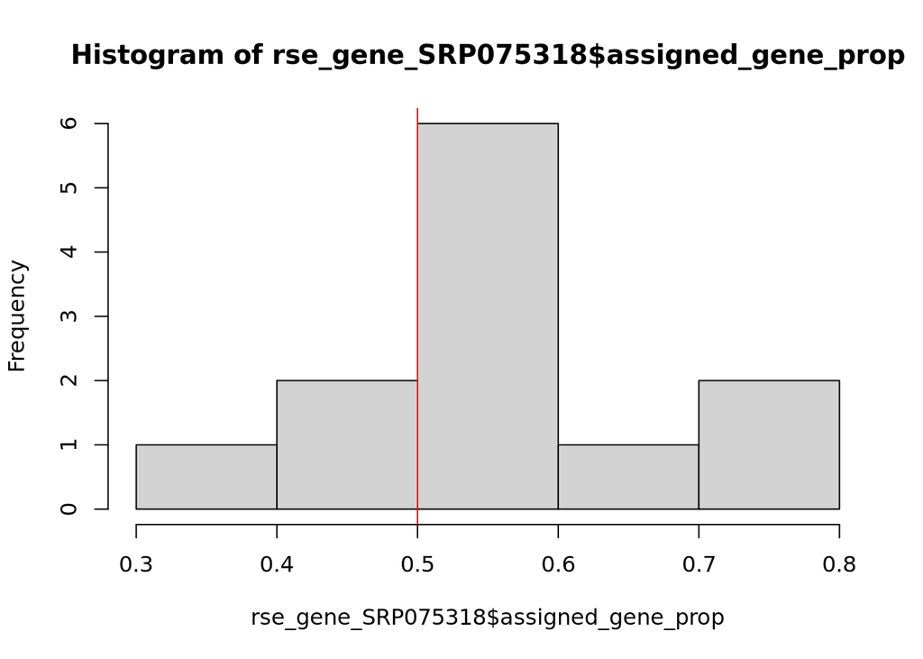

```r
## Guardemos nuestro objeto entero por si luego cambiamos de opinión
rse_gene_SRP075318_unfiltered <- rse_gene_SRP075318

## Eliminemos a muestras malas
hist(rse_gene_SRP075318$assigned_gene_prop)
abline(v=0.5, col='red')
```

```r
rse_gene_SRP075318 <- rse_gene_SRP075318[, rse_gene_SRP075318$assigned_gene_prop >= 0.5]
rse_gene_SRP075318
```

```
## class: RangedSummarizedExperiment
## dim: 63856 9
## metadata(8): time_created recount3_version ... annotation recount3_url
## assays(2): raw_counts counts
## rownames(63856): ENSG00000278704.1 ENSG00000277400.1 ...
##   ENSG00000182484.15_PAR_Y ENSG00000227159.8_PAR_Y
## rowData names(10): source type ... havana_gene tag
## colnames(9): SRR3543511 SRR3543512 ... SRR3543519 SRR3538932
## colData names(182): rail_id external_id ... sra_attribute.tissue
##   assigned_gene_prop
```

```r
gene_means <- rowMeans(assay(rse_gene_SRP075318 , "counts"))
summary(gene_means)
```

```
##     Min.  1st Qu.   Median     Mean  3rd Qu.     Max.
##     0.00     0.22     3.89   317.87   108.89 96439.00
```

Procedemos a limpiar los genes poco informativos:

```r
## Eliminamos genes
rse_gene_SRP075318 <- rse_gene_SRP075318[gene_means > 0.22, ]

## Dimensiones finales
dim(rse_gene_SRP075318)
```

```
## [1] 48701     9
```

```r
## Porcentaje de genes que retuvimos
round(nrow(rse_gene_SRP075318) / nrow(rse_gene_SRP075318_unfiltered) * 100, 2)
```

```
## [1] 76.27
```

## Normalización

```r
library("edgeR")
dge <- DGEList(
    counts = assay(rse_gene_SRP075318, "counts"),
    genes = rowData(rse_gene_SRP075318)
)
dge <- calcNormFactors(dge)
```

# Análisis de expresión diferencial

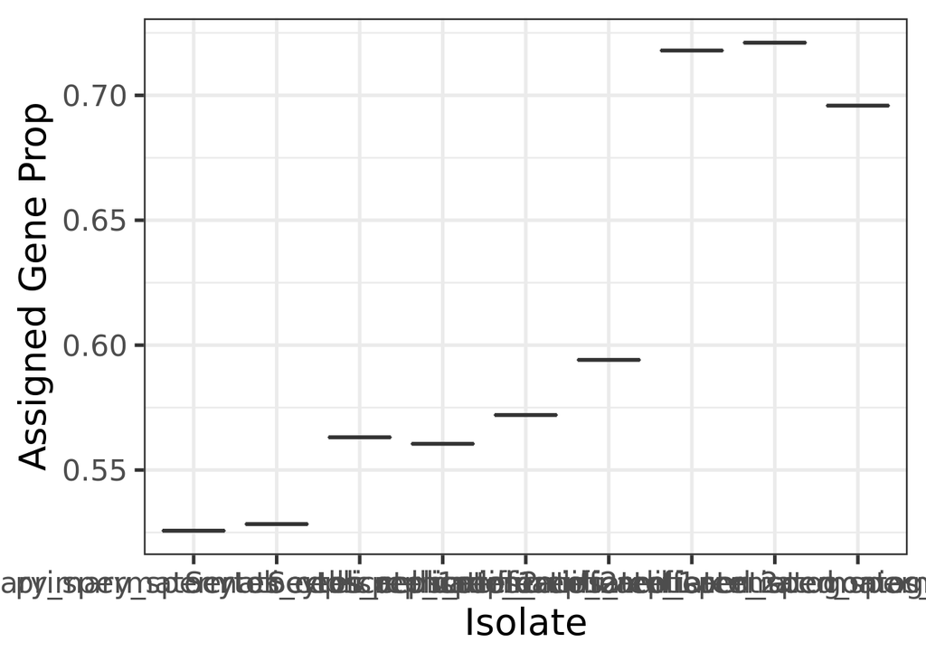

```r
library("ggplot2")
ggplot(as.data.frame(colData(rse_gene_SRP075318)), aes(y = assigned_gene_prop, x = sra_attribute.isolate)) +
    geom_boxplot() +
    theme_bw(base_size = 20) +
    ylab("Assigned Gene Prop") +
    xlab("Isolate")
```

```r
mod <- model.matrix(~ sra_attribute.isolate + sra_attribute.age,
    data = colData(rse_gene_SRP075318)
)
colnames(mod)
```

```
##  [1] "(Intercept)"
##  [2] "sra_attribute.isolateprimary_spermatocytes_replicate_2"
##  [3] "sra_attribute.isolateSertoli_cells_replicate_1"
##  [4] "sra_attribute.isolateSertoli_cells_replicate_2"
##  [5] "sra_attribute.isolatespermatids_replicate_1"
##  [6] "sra_attribute.isolatespermatids_replicate_2"
##  [7] "sra_attribute.isolateundifferentiated_spermatogonias_1"
##  [8] "sra_attribute.isolateundifferentiated_spermatogonias_2"
##  [9] "sra_attribute.isolateundifferentiated_spermatogonias_3"
## [10] "sra_attribute.age"
```

```r
library("limma")
vGene <- voom(dge, mod, plot = TRUE)
```

[output not shown]

```
## Coefficients not estimable: sra_attribute.age
```

Debido a que el experimento no tiene replicaciones (cada aislado corresponde a 1 muestra) no podemos aplicar análisis con limma.